# Metrics

Richard Wen richard.wen@unityhealth.to

February 12, 2024

## Libraries

```r
library(tidyverse)
```

```
R Version
---               _
platform       x86_64-apple-darwin20
arch           x86_64
os             darwin20
system         x86_64, darwin20
status
major          4
minor          3.1
year           2023
month          06
day            16
svn rev        84548
language       R
version.string R version 4.3.1 (2023-06-16)
nickname       Beagle Scouts

Package Versions
---
tidyverse 2.0.0
```

## Settings

```r
models_format <- c(
    "_cghr10" = "",
    "_" = " & ",
    "gpt3" = "GPT-3.5",
    "gpt4" = "GPT-4",
    "insilicova" = "InSilicoVA",
    "interva5" = "InterVA-5"
)
stage_format <- c(
    "is_" = "",
    "recon" = "Reconciliation",
    "agreed" = "Agreement",
    "adj" = "Adjudication"
)
```

## Functions

Functions for PCCC and CSMF Accuracy.

```r
# Calc PCCC
calc_pccc <- function(actual, pred, k = 1, N = NULL) {

    # Calc N num of causes if not known
    N <- if (is.null(N)) length(unique(na.omit(c(actual, pred)))) else N

    # Calc frac of deaths in top k causes
    TP <- actual == pred
    TP[is.na(TP) | is.null(TP)] <- FALSE # for no preds
    C <- sum(TP) / length(actual)

    # Calc PCCC
    out <- (C - (k/N)) / (1 - (k/N))
    return(out)
}

# Calc CSMF accuracy
calc_csmf_acc <- function(actual, pred) {

    # Get all unique causes
    causes <- unique(c(actual, pred))

    # Get csmfs
    cases <- length(actual)
    csmf_true <- table(actual) / cases
    csmf_pred <- table(pred) / cases

    # Correct for missing causes in either actual or pred
    csmf_true <- vapply(
        causes,
        function(x) if (x %in% names(csmf_true)) csmf_true[x] else 0,
        FUN.VALUE = numeric(1)
    )
    csmf_pred <- vapply(
        causes,
        function(x) if (x %in% names(csmf_pred)) csmf_pred[x] else 0,
        FUN.VALUE = numeric(1)
    )

    # Calc csmf max error
    csmf_max_error <- 2 * (1 - min(csmf_true))

    # Calc csmf acc
    out <- 1 - (sum(abs(csmf_true - csmf_pred)) / csmf_max_error)
    return(out)
}

# Bulk calc per model
calc_per_model <- function(actual, pred, func, name = "Metric", ...) {

    # Prep data in long format grouped by model
    out <- pred %>%
        pivot_longer( # to long format
            everything(),
            names_to = "Model",
            values_to = "prediction"
        ) %>% group_by(Model)

    # Calc k if pccc as it is diff for model combos
    if (identical(func, calc_pccc)) {
        out <- out %>%
            summarise(
                !!name := func(
                    actual,
                    prediction,
                    k = str_count(unique(Model), "_"),
                    ...
                )
            )
    } else { # otherwise apply func
        out <- out %>%
            summarise(
                !!name := func(
                    actual,
                    prediction,
                    ...
                )
            )
    }

    # Format display and return
    out <- out %>%
        mutate(Model = str_replace_all(Model, models_format)) %>%
        arrange(across({{name}}, desc))
    return(out)
}

# Bulk calc per model based on age, physician coding stage, and cause of death
calc_by <- function(
        df,
        func,
        name = "Metric",
        by_age = TRUE,
        by_stage = TRUE,
        by_sex = TRUE,
        by_cod = TRUE,
        by_age_range = TRUE,
        ...
    ) {
    out <- list()

    # Calc overall metric
    out[[name]] <- calc_per_model(
        actual = df %>% pull(physician_cghr10),
        pred = df %>% select(ends_with("_cghr10"), -physician_cghr10),
        func = func,
        ...
    ) %>% rename(
        {{ name }} := Metric
    )

    # Calc metric for va coding stage
    if (by_stage) {
        for (stage in c("is_agreed", "is_recon", "is_adj")) {

            # Filter data for stage
            df_filter <- df %>% filter(.[[stage]] == TRUE)
            metric_name = paste0(
                name,
                " ",
                str_replace_all(stage, stage_format)
            )

            # Calc metric for stage
            out[[metric_name]] <- calc_per_model(
                actual = df_filter %>%
                    pull(physician_cghr10),
                pred = df_filter %>%
                    select(ends_with("_cghr10"), -physician_cghr10),
                func = func,
                ...
            ) %>% rename(
                 {{ metric_name }} := Metric
            )
        }
    }

    # Calc pcc for each age group
    if (by_age) {
        for (age_group in c("adult", "child", "neo")) {

            # Filter data for age
            df_filter <- df %>% filter(age == age_group)
            metric_name = paste0(
                name,
                " ",
                str_to_title(age_group)
            )

            # Calc metric for age
            out[[metric_name]] <- calc_per_model(
                actual = df_filter %>%
                    pull(physician_cghr10),
                pred = df_filter %>%
                    select(ends_with("_cghr10"), -physician_cghr10),
                func = func,
                ...
            ) %>% rename(
                 {{ metric_name }} := Metric
            )

            # Calc metric for each stage within age group
            for (stage in c("is_agreed", "is_recon", "is_adj")) {

                # Filter data for stage within age group
                df_filter <- df %>% filter(
                    .[[stage]] == TRUE & age == age_group
                )
                metric_name <- paste0(
                    name,
                    " ",
                    str_to_title(age_group),
                    " ",
                    str_replace_all(stage, stage_format)
                )

                # Calc metric for stage within age group
                out[[metric_name]] <- calc_per_model(
                    actual = df_filter %>%
                        pull(physician_cghr10),
                    pred = df_filter %>%
                        select(ends_with("_cghr10"), -physician_cghr10),
                    func = func,
                    ...
                ) %>% rename(
                     {{ metric_name }} := Metric
                )
            }
        }
    }

    # Calc metric by sex for each age group
    if (by_sex) {

        # Calc metric by cod
        for (a in c("adult", "child", "neo")) {
            for (sx in c("Male", "Female")) {

                # Filter data for cod
                df_filter <- df %>% filter(
                    sex == sx & is_agreed == TRUE & age == a
                )
                metric_name <- sprintf(
                    "%s %s Sex Agree %s", name, str_to_title(a), sx
                )

                # Calc metric for cod
                if (nrow(df_filter) > 0) {
                    out[[metric_name]] <- calc_per_model(
                        actual = df_filter %>%
                            pull(physician_cghr10),
                        pred = df_filter %>%
                            select(ends_with("_cghr10"), -physician_cghr10),
                        func = func,
                        ...
                    ) %>% rename(
                         {{ metric_name }} := Metric
                    )
                }
            }
        }
    }

    # Calc metric by cause of death for each age group
    if (by_cod) {

        # Get unique causes of death
        causes <- df %>%
            select(ends_with("_cghr10")) %>%
            pivot_longer(
                everything(),
                names_to = "column",
                values_to = "cod"
            ) %>%
            distinct(cod) %>%
            filter(!is.na(cod)) %>%
            pull(cod)

        # Calc metric by cod
        for (a in c("adult", "child", "neo")) {
            for (cod in causes) {

                # Filter data for cod
                df_filter <- df %>% filter(
                    physician_cghr10 == cod & is_agreed == TRUE & age == a
                )
                metric_name <- sprintf(
                    "%s %s COD Agree %s", name, str_to_title(a), cod
                )

                # Calc metric for cod
                if (nrow(df_filter) > 0) {
                    out[[metric_name]] <- calc_per_model(
                        actual = df_filter %>%
                            pull(physician_cghr10),
                        pred = df_filter %>%
                            select(ends_with("_cghr10"), -physician_cghr10),
                        func = func,
                        ...
                    ) %>% rename(
                         {{ metric_name }} := Metric
                    )
                }
            }
        }
    }

    # Calc metric by age range
    if (by_age_range) {

        # Get unique age ranges
        age_ranges <- df %>%
            pull(age_range) %>%
            unique

        # Calc metric by age range
        for (a in c("adult", "child", "neo")) {
            for (ar in age_ranges) {

                # Filter for age range
                df_filter <- df %>% filter(
                    age_range == ar & is_agreed == TRUE & age == a
                )
                metric_name <- sprintf(
                    "%s %s Age Agree %s", name, str_to_title(a), ar
                )

                # Calc metric for cod
                if (nrow(df_filter) > 0) {
                    out[[metric_name]] <- calc_per_model(
                        actual = df_filter %>%
                            pull(physician_cghr10),
                        pred = df_filter %>%
                            select(ends_with("_cghr10"), -physician_cghr10),
                        func = func,
                        ...
                    ) %>% rename(
                         {{ metric_name }} := Metric
                    )
                }
            }
        }
    }

    # Combine all pccc metrics
    out <- reduce(out,
        function(x, y) left_join(x, y, by = "Model")
    ) %>%
        arrange(across({{ name }}, desc))
    return(out)
}
```

## Data

### Raw Data

Load data from `data` folder.

```r
raw_df <- read_csv("../data/healsl_rd1to2_cod_v1.csv")
```

```
Cases:  11920
```

| rowid | round | age | age_range | sex | p1_icd | p2_icd | p1_recon_icd | p2_recon_icd | adj_icd | is_agreed | is_recon | is_adj | physician_icd10 | gpt3_icd10 | gpt4_icd10 | insilicova_wva2016 | interva5_wva2016 | insilicova_icd10 | interva5_icd10 | physician_cghr10 | gpt3_cghr10 | gpt4_cghr10 | insilicova_cghr10 | interva5_cghr10 |
| --- | --- | --- | --- | --- | --- | --- | --- | --- | --- | --- | --- | --- | --- | --- | --- | --- | --- | --- | --- | --- | --- | --- | --- | --- |
| 14002421 | 1 | adult | 50-54 | Female | Y84 | B50 | Y84 | Y84 | NA | FALSE | TRUE | FALSE | Y84 | R99 | A41 | 1.03 | 1.03 | B24 | B24 | Other injuries | Ill-defined | Unspecified infections | Unspecified infections | Unspecified infections |
| 14005966 | 1 | adult | 25-29 | Male | V22 | V22 | NA | NA | NA | TRUE | FALSE | FALSE | V22 | V01 | S36 | 12.01 | 12.01 | V89 | V89 | Road and transport injuries | Road and transport injuries | Other injuries | Road and transport injuries | Road and transport injuries |
| 14001514 | 1 | adult | 25-29 | Female | B50 | B54 | NA | NA | NA | TRUE | FALSE | FALSE | B50 | B50 | B50 | 9.06 | 9.02 | O75 | O06 | Malaria | Malaria | Malaria | Maternal conditions | Maternal conditions |
| 14009193 | 1 | adult | 40-44 | Male | B24 | A19 | B24 | B24 | NA | FALSE | TRUE | FALSE | B24 | J18 | I11 | 4.99 | 2.03 | I99 | C39 | Unspecified infections | Acute respiratory infections | Other cardiovascular diseases | Other cardiovascular diseases | Cancers |
| 14002210 | 1 | adult | 40-44 | Female | I64 | I64 | NA | NA | NA | TRUE | FALSE | FALSE | I64 | I64 | I63 | 4.02 | 4.02 | I64 | I64 | Stroke | Stroke | Stroke | Stroke | Stroke |
| 14001130 | 1 | adult | 40-44 | Male | B50 | B54 | NA | NA | NA | TRUE | FALSE | FALSE | B50 | B50 | K70 | 1.03 | 1.03 | B24 | B24 | Malaria | Malaria | Liver and alcohol related diseases | Unspecified infections | Unspecified infections |

### Clean Labels

Clean `age_range` labels to include only values and unit of measure in titlecase.

```r
df <- raw_df %>% mutate(
    "age_range" = str_to_title(str_replace(
        age_range,
        "\\s*\\(.*\\)",
        ""
    )),
    "age_range" = if_else(
        !str_detect(age_range, "Year|Years|Day|Days|month|Months|week|Weeks"),
        paste0(age_range, " Years"),
        age_range
    )
)
df
```

| rowid | round | age | age_range | sex | p1_icd | p2_icd | p1_recon_icd | p2_recon_icd | adj_icd | is_agreed | is_recon | is_adj | physician_icd10 | gpt3_icd10 | gpt4_icd10 | insilicova_wva2016 | interva5_wva2016 | insilicova_icd10 | interva5_icd10 | physician_cghr10 | gpt3_cghr10 | gpt4_cghr10 | insilicova_cghr10 | interva5_cghr10 |
| --- | --- | --- | --- | --- | --- | --- | --- | --- | --- | --- | --- | --- | --- | --- | --- | --- | --- | --- | --- | --- | --- | --- | --- | --- |
| 14002421 | 1 | adult | 50-54 Years | Female | Y84 | B50 | Y84 | Y84 | NA | FALSE | TRUE | FALSE | Y84 | R99 | A41 | 1.03 | 1.03 | B24 | B24 | Other injuries | Ill-defined | Unspecified infections | Unspecified infections | Unspecified infections |
| 14005966 | 1 | adult | 25-29 Years | Male | V22 | V22 | NA | NA | NA | TRUE | FALSE | FALSE | V22 | V01 | S36 | 12.01 | 12.01 | V89 | V89 | Road and transport injuries | Road and transport injuries | Other injuries | Road and transport injuries | Road and transport injuries |
| 14001514 | 1 | adult | 25-29 Years | Female | B50 | B54 | NA | NA | NA | TRUE | FALSE | FALSE | B50 | B50 | B50 | 9.06 | 9.02 | O75 | O06 | Malaria | Malaria | Malaria | Maternal conditions | Maternal conditions |
| 14009193 | 1 | adult | 40-44 Years | Male | B24 | A19 | B24 | B24 | NA | FALSE | TRUE | FALSE | B24 | J18 | I11 | 4.99 | 2.03 | I99 | C39 | Unspecified infections | Acute respiratory infections | Other cardiovascular diseases | Other cardiovascular diseases | Cancers |
| 14002210 | 1 | adult | 40-44 Years | Female | I64 | I64 | NA | NA | NA | TRUE | FALSE | FALSE | I64 | I64 | I63 | 4.02 | 4.02 | I64 | I64 | Stroke | Stroke | Stroke | Stroke | Stroke |
| 14001130 | 1 | adult | 40-44 Years | Male | B50 | B54 | NA | NA | NA | TRUE | FALSE | FALSE | B50 | B50 | K70 | 1.03 | 1.03 | B24 | B24 | Malaria | Malaria | Liver and alcohol related diseases | Unspecified infections | Unspecified infections |
| 14003027 | 1 | adult | 10-14 Years | Male | D57 | D57 | NA | NA | NA | TRUE | FALSE | FALSE | D57 | D57 | D57 | 3.02 | 3.02 | E46 | E46 | Other noncommunicable diseases | Other noncommunicable diseases | Other noncommunicable diseases | Nutritional deficiencies | Nutritional deficiencies |
| 14005589 | 1 | adult | 20-24 Years | Male | N13 | K76 | N13 | K76 | N13 | FALSE | TRUE | TRUE | N13 | N13 | B15 | 1.99 | 6.02 | B99 | K74 | Other noncommunicable diseases | Other noncommunicable diseases | Unspecified infections | Unspecified infections | Liver and alcohol related diseases |
| 14007630 | 1 | adult | 40-44 Years | Male | V44 | V44 | NA | NA | NA | TRUE | FALSE | FALSE | V44 | S06 | V89 | 12.01 | 12.01 | V89 | V89 | Road and transport injuries | Other injuries | Road and transport injuries | Road and transport injuries | Road and transport injuries |
| 14002208 | 1 | adult | 65-69 Years | Female | B54 | A01 | A01 | A01 | NA | FALSE | TRUE | FALSE | A01 | B50 | B50 | 98.00 | 1.09 | R99 | A16 | Diarrhoeal diseases | Malaria | Malaria | Ill-defined | Tuberculosis |

[output cut: 990 more lines]

### Physician Cases

Filter for cases that were coded by physicians.

```r
df <- df %>%
    filter(!is.na(physician_cghr10) & !is.null(physician_cghr10))
```

```
Physician Coded Cases:  11799
```

| rowid | round | age | age_range | sex | p1_icd | p2_icd | p1_recon_icd | p2_recon_icd | adj_icd | is_agreed | is_recon | is_adj | physician_icd10 | gpt3_icd10 | gpt4_icd10 | insilicova_wva2016 | interva5_wva2016 | insilicova_icd10 | interva5_icd10 | physician_cghr10 | gpt3_cghr10 | gpt4_cghr10 | insilicova_cghr10 | interva5_cghr10 |
| --- | --- | --- | --- | --- | --- | --- | --- | --- | --- | --- | --- | --- | --- | --- | --- | --- | --- | --- | --- | --- | --- | --- | --- | --- |
| 14002421 | 1 | adult | 50-54 Years | Female | Y84 | B50 | Y84 | Y84 | NA | FALSE | TRUE | FALSE | Y84 | R99 | A41 | 1.03 | 1.03 | B24 | B24 | Other injuries | Ill-defined | Unspecified infections | Unspecified infections | Unspecified infections |
| 14005966 | 1 | adult | 25-29 Years | Male | V22 | V22 | NA | NA | NA | TRUE | FALSE | FALSE | V22 | V01 | S36 | 12.01 | 12.01 | V89 | V89 | Road and transport injuries | Road and transport injuries | Other injuries | Road and transport injuries | Road and transport injuries |
| 14001514 | 1 | adult | 25-29 Years | Female | B50 | B54 | NA | NA | NA | TRUE | FALSE | FALSE | B50 | B50 | B50 | 9.06 | 9.02 | O75 | O06 | Malaria | Malaria | Malaria | Maternal conditions | Maternal conditions |
| 14009193 | 1 | adult | 40-44 Years | Male | B24 | A19 | B24 | B24 | NA | FALSE | TRUE | FALSE | B24 | J18 | I11 | 4.99 | 2.03 | I99 | C39 | Unspecified infections | Acute respiratory infections | Other cardiovascular diseases | Other cardiovascular diseases | Cancers |
| 14002210 | 1 | adult | 40-44 Years | Female | I64 | I64 | NA | NA | NA | TRUE | FALSE | FALSE | I64 | I64 | I63 | 4.02 | 4.02 | I64 | I64 | Stroke | Stroke | Stroke | Stroke | Stroke |
| 14001130 | 1 | adult | 40-44 Years | Male | B50 | B54 | NA | NA | NA | TRUE | FALSE | FALSE | B50 | B50 | K70 | 1.03 | 1.03 | B24 | B24 | Malaria | Malaria | Liver and alcohol related diseases | Unspecified infections | Unspecified infections |

### Combined Models

Create model combinations where if any of the models have the physician code, then set the combined model’s output for the case to be the physician code.

```r
df <- df %>%
    mutate( # Combine models
        "gpt3_insilicova_cghr10" = if_else(
            gpt3_cghr10 == physician_cghr10 |
                insilicova_cghr10 == physician_cghr10,
            physician_cghr10,
            gpt3_cghr10
        ),
        "gpt4_insilicova_cghr10" = if_else(
            gpt4_cghr10 == physician_cghr10 |
                insilicova_cghr10 == physician_cghr10,
            physician_cghr10,
            gpt4_cghr10
        ),
        "gpt3_interva5_cghr10" = if_else(
            gpt3_cghr10 == physician_cghr10 |
                interva5_cghr10 == physician_cghr10,
            physician_cghr10,
            gpt3_cghr10
        ),
        "gpt4_interva5_cghr10" = if_else(
            gpt4_cghr10 == physician_cghr10 |
                interva5_cghr10 == physician_cghr10,
            physician_cghr10,
            gpt4_cghr10
        ),
        "gpt3_insilicova_interva5_cghr10" = if_else(
            gpt3_cghr10 == physician_cghr10 |
                insilicova_cghr10 == physician_cghr10 |
                interva5_cghr10 == physician_cghr10,
            physician_cghr10,
            gpt3_cghr10
        ),
        "gpt4_insilicova_interva5_cghr10" = if_else(
            gpt4_cghr10 == physician_cghr10 |
                insilicova_cghr10 == physician_cghr10 |
                interva5_cghr10 == physician_cghr10,
            physician_cghr10,
            gpt4_cghr10
        )
    )
```

| gpt3_insilicova_cghr10 | gpt4_insilicova_cghr10 | gpt3_interva5_cghr10 | gpt4_interva5_cghr10 | gpt3_insilicova_interva5_cghr10 | gpt4_insilicova_interva5_cghr10 |
| --- | --- | --- | --- | --- | --- |
| Ill-defined | Unspecified infections | Ill-defined | Unspecified infections | Ill-defined | Unspecified infections |
| Road and transport injuries | Road and transport injuries | Road and transport injuries | Road and transport injuries | Road and transport injuries | Road and transport injuries |
| Malaria | Malaria | Malaria | Malaria | Malaria | Malaria |
| Acute respiratory infections | Other cardiovascular diseases | Acute respiratory infections | Other cardiovascular diseases | Acute respiratory infections | Other cardiovascular diseases |
| Stroke | Stroke | Stroke | Stroke | Stroke | Stroke |
| Malaria | Liver and alcohol related diseases | Malaria | Liver and alcohol related diseases | Malaria | Liver and alcohol related diseases |

### Prepared Data

Display case counts for raw data and prepared data after combining models and filtering for physician coded cases.

```r
cat("\nRaw Data\n--------\n\n")
```

```
Raw Data
--------
```

```r
# Physician info
raw_physicians <- raw_df$physician_cghr10
cat(paste0(
    "Cases (",
    length(unique(na.omit(raw_physicians))), " CODs): ",
    length(raw_physicians),
    "\n"
))
```

```
Cases (29 CODs): 11920
```

```r
# Physician agreed cases
raw_physicians_agree <- raw_df %>%
    filter(is_agreed == TRUE) %>%
    pull(physician_cghr10)
cat(paste0(
    "Agreed Cases (",
    length(unique(na.omit(raw_physicians_agree))), " CODs): ",
    length(raw_physicians_agree),
    "\n"
))
```

```
Agreed Cases (29 CODs): 7042
```

```r
# Models cases
raw_models <- raw_df %>% select(ends_with("_cghr10"), -physician_cghr10)
for (mcol in colnames(raw_models)) {
    m <- raw_models[[mcol]]
    cat(paste0(
        str_replace_all(mcol, models_format), " Predicted Cases (",
        length(unique(na.omit(m))), " CODs): ",
        length(m) - sum(is.na(m) | is.null(m)),
        "\n"
    ))
}
```

```
GPT-3.5 Predicted Cases (29 CODs): 11785
GPT-4 Predicted Cases (29 CODs): 11703
InSilicoVA Predicted Cases (29 CODs): 11548
InterVA-5 Predicted Cases (28 CODs): 11665
```

```r
cat("\nPrepared Data\n--------------\n")
```

```
Prepared Data
--------------
```

```r
# Physician cases
physicians <- df$physician_cghr10
cat(paste0(
    "Physician Coded Cases (",
    length(unique(na.omit(physicians))), " CODs): ",
    length(physicians) - sum(is.na(physicians) | is.null(physicians)),
    "\n"
))
```

```
Physician Coded Cases (29 CODs): 11799
```

```r
# Physician agreed cases
physicians_agree <- df %>%
    filter(is_agreed == TRUE) %>%
    pull(physician_cghr10)
cat(paste0(
    "Physician Agreed Coded Cases (",
    length(unique(na.omit(physicians_agree))), " CODs): ",
    length(physicians_agree) - sum(is.na(physicians_agree) | is.null(physicians_agree)),
    "\n"
))
```

```
Physician Agreed Coded Cases (29 CODs): 6939
```

```r
# Models cases
models <- df %>% select(ends_with("_cghr10"), -physician_cghr10)
for (mcol in colnames(models)) {
    m <- models[[mcol]]
    cat(paste0(
        str_replace_all(mcol, models_format), " Predicted Cases (",
        length(unique(na.omit(m))), " CODs): ",
        length(m) - sum(is.na(m) | is.null(m)),
        "\n"
    ))
}
```

```
GPT-3.5 Predicted Cases (29 CODs): 11707
GPT-4 Predicted Cases (29 CODs): 11628
InSilicoVA Predicted Cases (29 CODs): 11460
InterVA-5 Predicted Cases (28 CODs): 11575
GPT-3.5 & InSilicoVA Predicted Cases (29 CODs): 11598
GPT-4 & InSilicoVA Predicted Cases (29 CODs): 11550
GPT-3.5 & InterVA-5 Predicted Cases (29 CODs): 11639
GPT-4 & InterVA-5 Predicted Cases (29 CODs): 11577
GPT-3.5 & InSilicoVA & InterVA-5 Predicted Cases (29 CODs): 11618
GPT-4 & InSilicoVA & InterVA-5 Predicted Cases (29 CODs): 11572
```

```r
# Models agreed cases
models_agree <- df %>%
    filter(is_agreed == TRUE) %>%
    select(ends_with("_cghr10"), -physician_cghr10)
for (mcol in colnames(models_agree)) {
    m <- models_agree[[mcol]]
    cat(paste0(
        str_replace_all(mcol, models_format), " Agreed Predicted Cases (",
        length(unique(na.omit(m))), " CODs): ",
        length(m) - sum(is.na(m) | is.null(m)),
        "\n"
    ))
}
```

```
GPT-3.5 Agreed Predicted Cases (29 CODs): 6892
GPT-4 Agreed Predicted Cases (29 CODs): 6856
InSilicoVA Agreed Predicted Cases (29 CODs): 6726
InterVA-5 Agreed Predicted Cases (28 CODs): 6802
GPT-3.5 & InSilicoVA Agreed Predicted Cases (29 CODs): 6838
GPT-4 & InSilicoVA Agreed Predicted Cases (29 CODs): 6822
GPT-3.5 & InterVA-5 Agreed Predicted Cases (29 CODs): 6861
GPT-4 & InterVA-5 Agreed Predicted Cases (29 CODs): 6837
GPT-3.5 & InSilicoVA & InterVA-5 Agreed Predicted Cases (29 CODs): 6850
GPT-4 & InSilicoVA & InterVA-5 Agreed Predicted Cases (29 CODs): 6836
```

## Metrics

Calculate metrics from model outputs compared to physician codes.

```r
metrics <- list()
```

### PCCC

Calculate Partial Chance Corrected Concordance (PCCC) to evaluate indivudal performance for each model by age and physician coding stage.

```r
# Get num of unique causes
ncauses <- df %>%
    select(ends_with("_cghr10")) %>%
    pivot_longer(
        everything(),
        names_to = "column",
        values_to = "cod"
    ) %>%
    distinct(cod) %>%
    filter(!is.na(cod)) %>%
    pull(cod) %>%
    length

# Calc pccc for age, stage, and cod
metrics$pccc <- calc_by(df, calc_pccc, "PCCC", N = ncauses)
metrics$pccc
```

| Model | PCCC | PCCC Agreement | PCCC Reconciliation | PCCC Adjudication | PCCC Adult | PCCC Adult Agreement | PCCC Adult Reconciliation | PCCC Adult Adjudication | PCCC Child | PCCC Child Agreement | PCCC Child Reconciliation | PCCC Child Adjudication | PCCC Neo | PCCC Neo Agreement | PCCC Neo Reconciliation | PCCC Neo Adjudication | PCCC Adult Sex Agree Male | PCCC Adult Sex Agree Female | PCCC Child Sex Agree Male | PCCC Child Sex Agree Female | PCCC Neo Sex Agree Male | PCCC Neo Sex Agree Female | PCCC Adult COD Agree Other injuries | PCCC Adult COD Agree Ill-defined | PCCC Adult COD Agree Unspecified infections | PCCC Adult COD Agree Road and transport injuries | PCCC Adult COD Agree Malaria | PCCC Adult COD Agree Maternal conditions | PCCC Adult COD Agree Acute respiratory infections | … |
| --- | --- | --- | --- | --- | --- | --- | --- | --- | --- | --- | --- | --- | --- | --- | --- | --- | --- | --- | --- | --- | --- | --- | --- | --- | --- | --- | --- | --- | --- | --- |
| GPT-4 & InSilicoVA & InterVA-5 | 0.7302998 | 0.8141829 | 0.6105334 | 0.6247078 | 0.6847478 | 0.7906832 | 0.5558328 | 0.5716630 | 0.7941982 | 0.8409011 | 0.7049889 | 0.7268738 | 0.8051850 | 0.8550234 | 0.7344322 | 0.7354536 | 0.8107226 | 0.7651123 | 0.8508401 | 0.8305307 | 0.8572308 | 0.8525923 | 0.9375135 | 0.46614070 | 0.7362072 | 0.8889059 | 0.7110330 | 0.9914201 | 0.8725275 | … |
| GPT-4 & InterVA-5 | 0.7044225 | 0.7884048 | 0.5845146 | 0.5950850 | 0.6660662 | 0.7723277 | 0.5367543 | 0.5469852 | 0.7590287 | 0.8076772 | 0.6661031 | 0.6860399 | 0.7635187 | 0.8108549 | 0.6963183 | 0.7039411 | 0.7841837 | 0.7571992 | 0.8084860 | 0.8068332 | 0.8023704 | 0.8201991 | 0.9217761 | 0.34821146 | 0.6686661 | 0.8887413 | 0.7042600 | 0.9917379 | 0.7954145 | … |
| GPT-3.5 & InSilicoVA & InterVA-5 | 0.7031691 | 0.7878213 | 0.5823045 | 0.6045308 | 0.6521024 | 0.7556999 | 0.5260325 | 0.5478665 | 0.7769786 | 0.8273608 | 0.6807414 | 0.7182939 | 0.7763743 | 0.8269634 | 0.7045559 | 0.6997041 | 0.7680832 | 0.7398984 | 0.8326094 | 0.8218843 | 0.8349231 | 0.8181972 | 0.8531566 | 0.62820513 | 0.6989322 | 0.9466748 | 0.6970733 | 1.0000000 | 0.8406593 | … |
| GPT-4 & InSilicoVA | 0.7022378 | 0.7916553 | 0.5745694 | 0.5892560 | 0.6617514 | 0.7756965 | 0.5230892 | 0.5405219 | 0.7598310 | 0.8097145 | 0.6645464 | 0.6846629 | 0.7648399 | 0.8198618 | 0.6867284 | 0.6832858 | 0.7957006 | 0.7501708 | 0.8236476 | 0.7951766 | 0.8109630 | 0.8296623 | 0.9368192 | 0.48591326 | 0.7045606 | 0.8930205 | 0.6787188 | 0.9917379 | 0.8772487 | … |
| GPT-3.5 & InSilicoVA | 0.6726527 | 0.7620908 | 0.5449550 | 0.5659404 | 0.6260003 | 0.7383594 | 0.4892682 | 0.5093808 | 0.7408422 | 0.7913786 | 0.6443103 | 0.6805318 | 0.7357751 | 0.7905893 | 0.6579586 | 0.6557455 | 0.7501338 | 0.7233349 | 0.7957185 | 0.7868504 | 0.7851852 | 0.7965410 | 0.8315178 | 0.64197531 | 0.6659050 | 0.9486498 | 0.6719974 | 1.0000000 | 0.8465608 | … |
| GPT-3.5 & InterVA-5 | 0.6711962 | 0.7555897 | 0.5507011 | 0.5729351 | 0.6275413 | 0.7299375 | 0.5029333 | 0.5217198 | 0.7376328 | 0.7913786 | 0.6349705 | 0.6722697 | 0.7172794 | 0.7635686 | 0.6515653 | 0.6764008 | 0.7336096 | 0.7252517 | 0.7893347 | 0.7935113 | 0.7722963 | 0.7539566 | 0.8315178 | 0.55017411 | 0.6327716 | 0.9272539 | 0.6894730 | 0.9917379 | 0.6828924 | … |
| GPT-4 | 0.6061319 | 0.7089432 | 0.4593401 | 0.4626576 | 0.5849713 | 0.7084516 | 0.4347056 | 0.4379494 | 0.6515812 | 0.7269266 | 0.5076605 | 0.5113553 | 0.5630381 | 0.6135070 | 0.4913903 | 0.5086996 | 0.7165668 | 0.6980964 | 0.7291446 | 0.7246124 | 0.5815714 | 0.6486784 | 0.9071629 | 0.37148962 | 0.5340617 | 0.7771770 | 0.6383426 | 0.9840659 | 0.7632653 | … |
| GPT-3.5 | 0.5388047 | 0.6355074 | 0.4007349 | 0.4098227 | 0.5066612 | 0.6166828 | 0.3727735 | 0.3818576 | 0.6085124 | 0.6852780 | 0.4618789 | 0.4781593 | 0.4700404 | 0.5114555 | 0.4112457 | 0.3958333 | 0.6030969 | 0.6340189 | 0.6775897 | 0.6933001 | 0.5028571 | 0.5209251 | 0.6663665 | 0.56623932 | 0.4834741 | 0.5914912 | 0.6150098 | 0.9601648 | 0.6448980 | … |
| InSilicoVA | 0.3924758 | 0.4381858 | 0.3272119 | 0.3457463 | 0.3479606 | 0.4117598 | 0.2703222 | 0.2861050 | 0.4447478 | 0.4538532 | 0.4273551 | 0.4675366 | 0.5159023 | 0.5635669 | 0.4482355 | 0.4356685 | 0.4534133 | 0.3586088 | 0.4782955 | 0.4283499 | 0.5650000 | 0.5619887 | 0.4052621 | 0.15018315 | 0.4248990 | 0.8431986 | 0.2740926 | 0.8725275 | 0.5955782 | … |
| InterVA-5 | 0.3836100 | 0.4311706 | 0.3157040 | 0.3337554 | 0.3484064 | 0.4082406 | 0.2755930 | 0.2906377 | 0.4285003 | 0.4538532 | 0.3800725 | 0.4130952 | 0.4636707 | 0.4897424 | 0.4266582 | 0.4423077 | 0.4316850 | 0.3783250 | 0.4636754 | 0.4436047 | 0.4987143 | 0.4798615 | 0.4893958 | -0.03571429 | 0.3636614 | 0.8143142 | 0.3414983 | 0.7928571 | 0.2602041 | … |

### CSMF Accuracy

Calculate Cause Specific Mortality Fraction (CSMF) Accuracy to evaluate population performance for each model by age and physician coding stage.

```r
metrics$csmf_acc <- calc_by(
    df,
    calc_csmf_acc,
    "CSMF Accuracy",
    by_cod = FALSE
)
metrics$csmf_acc
```

| Model | CSMF Accuracy | CSMF Accuracy Agreement | CSMF Accuracy Reconciliation | CSMF Accuracy Adjudication | CSMF Accuracy Adult | CSMF Accuracy Adult Agreement | CSMF Accuracy Adult Reconciliation | CSMF Accuracy Adult Adjudication | CSMF Accuracy Child | CSMF Accuracy Child Agreement | CSMF Accuracy Child Reconciliation | CSMF Accuracy Child Adjudication | CSMF Accuracy Neo | CSMF Accuracy Neo Agreement | CSMF Accuracy Neo Reconciliation | CSMF Accuracy Neo Adjudication | CSMF Accuracy Adult Sex Agree Male | CSMF Accuracy Adult Sex Agree Female | CSMF Accuracy Child Sex Agree Male | CSMF Accuracy Child Sex Agree Female | CSMF Accuracy Neo Sex Agree Male | CSMF Accuracy Neo Sex Agree Female | CSMF Accuracy Adult Age Agree 50-54 Years | CSMF Accuracy Adult Age Agree 25-29 Years | CSMF Accuracy Adult Age Agree 40-44 Years | CSMF Accuracy Adult Age Agree 10-14 Years | CSMF Accuracy Adult Age Agree 20-24 Years | CSMF Accuracy Adult Age Agree 65-69 Years | CSMF Accuracy Adult Age Agree 45-49 Years | … |
| --- | --- | --- | --- | --- | --- | --- | --- | --- | --- | --- | --- | --- | --- | --- | --- | --- | --- | --- | --- | --- | --- | --- | --- | --- | --- | --- | --- | --- | --- | --- |
| GPT-4 & InSilicoVA & InterVA-5 | 0.9252903 | 0.9337801 | 0.9055556 | 0.8862156 | 0.9088235 | 0.9219812 | 0.8823155 | 0.8572210 | 0.9429781 | 0.9402504 | 0.9365942 | 0.9410256 | 0.9790898 | 0.9675052 | 0.9866071 | 0.9391026 | 0.9284382 | 0.9077930 | 0.9450223 | 0.9352713 | 0.948 | 0.9713656 | 0.8860947 | 0.9232955 | 0.9075235 | 0.9333333 | 0.9163636 | 0.9095652 | 0.9000000 | … |
| GPT-3.5 & InSilicoVA & InterVA-5 | 0.9187643 | 0.9205217 | 0.9032922 | 0.8954414 | 0.9099713 | 0.9073445 | 0.8947201 | 0.8864880 | 0.9321464 | 0.9332322 | 0.9235507 | 0.9121795 | 0.9206642 | 0.9496855 | 0.8705357 | 0.8782051 | 0.9125874 | 0.8964902 | 0.9368499 | 0.9279070 | 0.956 | 0.9339207 | 0.8535503 | 0.9403409 | 0.8777429 | 0.9074074 | 0.9218182 | 0.8800000 | 0.8841270 | … |
| GPT-4 & InterVA-5 | 0.9166879 | 0.9272229 | 0.8975309 | 0.8686686 | 0.9040890 | 0.9217198 | 0.8769084 | 0.8424508 | 0.9304034 | 0.9267830 | 0.9242754 | 0.9160256 | 0.9569496 | 0.9423480 | 0.9717262 | 0.9198718 | 0.9235431 | 0.9080904 | 0.9297920 | 0.9236434 | 0.922 | 0.9559471 | 0.8860947 | 0.9147727 | 0.9012539 | 0.9185185 | 0.9163636 | 0.9086957 | 0.8904762 | … |
| GPT-4 & InSilicoVA | 0.9101195 | 0.9200894 | 0.8839506 | 0.8654124 | 0.8946915 | 0.9111343 | 0.8584606 | 0.8331510 | 0.9255478 | 0.9258346 | 0.9170290 | 0.9250000 | 0.9661747 | 0.9433962 | 0.9717262 | 0.9391026 | 0.9191142 | 0.8967876 | 0.9323923 | 0.9182171 | 0.914 | 0.9669604 | 0.8683432 | 0.9247159 | 0.9043887 | 0.9333333 | 0.9054545 | 0.8930435 | 0.8841270 | … |
| GPT-3.5 & InterVA-5 | 0.9080431 | 0.9100735 | 0.8919753 | 0.8778944 | 0.9050215 | 0.9044694 | 0.8859733 | 0.8739059 | 0.9117281 | 0.9131259 | 0.9054348 | 0.8794872 | 0.9120541 | 0.9360587 | 0.8630952 | 0.8717949 | 0.9055944 | 0.8953004 | 0.9160475 | 0.9100775 | 0.930 | 0.9295154 | 0.8387574 | 0.9403409 | 0.8620690 | 0.8925926 | 0.9254545 | 0.8834783 | 0.8841270 | … |
| GPT-3.5 & InSilicoVA | 0.9041868 | 0.9045251 | 0.8847737 | 0.8706585 | 0.8986370 | 0.8947987 | 0.8765903 | 0.8594092 | 0.9102341 | 0.9125569 | 0.9036232 | 0.8942308 | 0.9157442 | 0.9318658 | 0.8601190 | 0.8461538 | 0.9004662 | 0.8845925 | 0.9145617 | 0.9081395 | 0.912 | 0.9361233 | 0.8402367 | 0.9318182 | 0.8699060 | 0.9074074 | 0.9109091 | 0.8660870 | 0.8650794 | … |
| GPT-4 | 0.8757098 | 0.8918432 | 0.8409465 | 0.8028220 | 0.8690818 | 0.8950601 | 0.8237913 | 0.7844639 | 0.8941733 | 0.9002276 | 0.8681159 | 0.8320513 | 0.8302583 | 0.8134172 | 0.8541667 | 0.8205128 | 0.8918415 | 0.8813206 | 0.8985884 | 0.8965116 | 0.750 | 0.8700441 | 0.8269231 | 0.9076705 | 0.8934169 | 0.9037037 | 0.8854545 | 0.8765217 | 0.8539683 | … |
| GPT-3.5 | 0.8659208 | 0.8620118 | 0.8418724 | 0.8154848 | 0.8708752 | 0.8676163 | 0.8452608 | 0.8213895 | 0.8586902 | 0.8641882 | 0.8315217 | 0.7942308 | 0.8591636 | 0.8050314 | 0.8526786 | 0.8333333 | 0.8720280 | 0.8536585 | 0.8618128 | 0.8666667 | 0.760 | 0.8237885 | 0.7721893 | 0.9076705 | 0.8134796 | 0.8592593 | 0.8868613 | 0.8286957 | 0.8047619 | … |
| InterVA-5 | 0.8063395 | 0.7785704 | 0.8221193 | 0.8044501 | 0.7456241 | 0.7151072 | 0.7697201 | 0.7664114 | 0.8718875 | 0.8247344 | 0.8844203 | 0.8737179 | 0.7706027 | 0.7431866 | 0.8066465 | 0.7935484 | 0.7398601 | 0.6823319 | 0.8335810 | 0.8139535 | 0.752 | 0.7334802 | 0.6849112 | 0.7230114 | 0.6880878 | 0.7666667 | 0.7454545 | 0.7530435 | 0.7015873 | … |
| InSilicoVA | 0.7853632 | 0.7376423 | 0.8197531 | 0.8225398 | 0.7404591 | 0.6837428 | 0.7732188 | 0.7746171 | 0.8157371 | 0.7492413 | 0.9014493 | 0.8967949 | 0.9009840 | 0.8794549 | 0.8640483 | 0.8838710 | 0.7067599 | 0.6537775 | 0.7447994 | 0.7538760 | 0.872 | 0.8568282 | 0.6878698 | 0.7201705 | 0.6849530 | 0.6629630 | 0.7127273 | 0.6660870 | 0.6285714 | … |

## Plots

Save calculated metrics to `data` folder.

```r
out <- reduce(metrics,
              function(x, y) left_join(x, y, by = "Model")
)
write_csv(out, "../data/healsl_rd1to2_metrics_v1.csv")
```

### Exploration

```r
# Num and perc of agreed cases
nall <- nrow(df)
nagree <- nrow(df %>% filter(is_agreed == TRUE))
pagree <- (nagree / nall) * 100

# Create labels to axis titles
y_title <- paste0("Physician Agreed Records (n=", nagree, ", 100%)")
```

#### Cases by Sex and Age Group

Display a plot of cases by age group separated by sex.

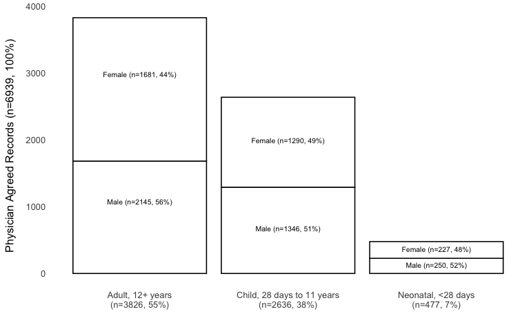

```r
# Calc age and sex counts
nadult <- nrow(df %>% filter(age == "adult" & is_agreed == TRUE))
nchild <- nrow(df %>% filter(age == "child" & is_agreed == TRUE))
nneo <- nrow(df %>% filter(age == "neo" & is_agreed == TRUE))

# Calc age and sex perc
padult <- (nadult / nagree) * 100
pchild <- (nchild / nagree) * 100
pneo <- (nneo / nagree) * 100

# Create age with counts
age_remap <- c(
    "Adult" = paste0("Adult, 12+ years\n(n=", nadult, ", ", round(padult), "%)"),
    "Child" = paste0("Child, 28 days to 11 years\n(n=", nchild, ", ", round(pchild), "%)"),
    "Neo" = paste0("Neonatal, <28 days\n(n=", nneo, ", ", round(pneo), "%)")
)

# Format the data for plotting
asdata <- df %>%
    filter(is_agreed == TRUE) %>%
    group_by(age, sex) %>%
    summarize(count = n()) %>%
    mutate(
        age = str_to_title(age),
        sex = paste0(
            sex, " (n=", count, ", ",
            round(count / case_when(
                age == "Adult" ~ nadult,
                age == "Child" ~ nchild,
                age == "Neo" ~ nneo
            ) * 100), "%)"
        )
    ) %>%
    mutate( # re-order age
        age = factor(age, levels = c(
            "Adult",
            "Child",
            "Neo"
        ))
    ) %>%
    mutate( # rename ages with counts
        age = recode(age, !!!age_remap)
    )
# Plot the data
asplot <- asdata %>%
    ggplot(aes(x = factor(age), y = count, fill = sex)) +
    geom_bar(
        stat = "identity",
        fill = "white",
        color = "black"
    ) +
    geom_text(
        aes(label = sex),
        position = position_stack(vjust = 0.5),
        size = 2.5,
        color = "black"
    ) +
    labs(
        y = y_title,
        x = element_blank(),
        fill = "Sex"
    ) +
    theme_minimal() +
    theme(
        panel.grid = element_blank(),
        axis.title.x = element_text(margin = margin(t = 10)),
        axis.title.y = element_text(margin = margin(r = 10))
    )

# Save the plot
asplot
ggsave("../manuscript/fig-data-agesex.pdf", plot = asplot, dpi = 300)
```

#### Cases by Age Range

Display a plot for each age group of cases by age range.

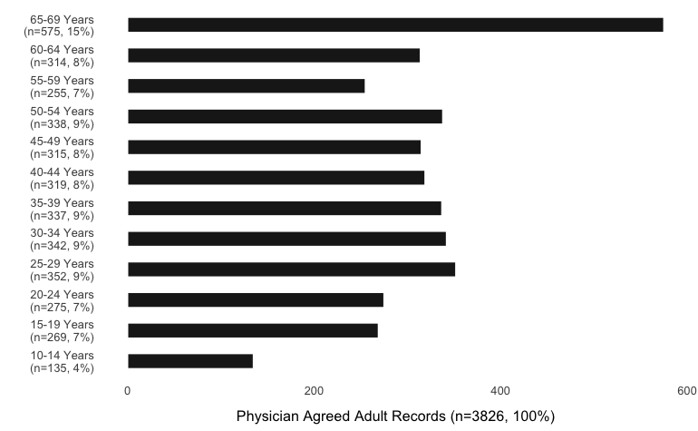

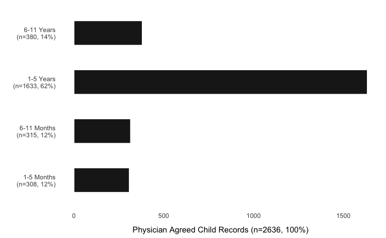

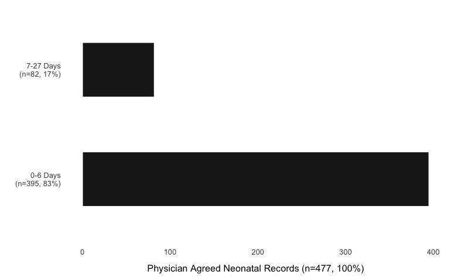

```r
for (a in c("adult", "child", "neo")) {

    # Create label for age group
    arows <- df %>% filter(is_agreed == TRUE & age == a) %>% nrow
    alabel <- if (a == "neo") "Neonatal" else str_to_title(a)
    atitle <- paste0("Physician Agreed ", alabel, " Records (n=", arows, ", 100%)")

    # Format plot data
    eardata <- df %>%
        filter(is_agreed == TRUE & age == a) %>%
        group_by(age_range) %>%
        summarize(count = n()) %>%
        separate(
            age_range,
            into = c("age_range_value", "age_range_unit"),
            sep = " "
        ) %>%
        separate(
            age_range_value,
            into = c("age_range_min", "age_range_max"),
            sep = "-"
        ) %>%
        mutate(
            age_range_min = as.integer(age_range_min),
            age_range_max = as.integer(age_range_max),
            age_range_unit = factor(age_range_unit, levels = c(
                "Weeks",
                "Days",
                "Months",
                "Years"
            )),
            age_range_label = paste0(
                age_range_min,
                "-",
                age_range_max,
                " ",
                age_range_unit,
                "\n(n=", count, ", ", round((count / arows) * 100), "%)"
            )
        ) %>%
        arrange(age_range_unit, age_range_min, age_range_max) %>%
        mutate(
            age_range_label = factor(age_range_label, levels = unique(age_range_label))
        )

    # Plot the data
    earplot <- eardata %>%
        ggplot(aes(x = age_range_label, y = count)) +
        geom_bar(
            stat = "identity",
            fill = "#1d1d1d",
            color = "white",
            width = 0.5
        ) +
        labs(
            y = atitle,
            x = element_blank()
        ) +
        theme_minimal() +
        theme(
            panel.grid = element_blank(),
            axis.title.x = element_text(margin = margin(t = 10)),
            axis.title.y = element_text(margin = margin(r = 10))
        ) +
        coord_flip()

    # Save the plot
    print(earplot)
    ggsave(
        sprintf("../manuscript/fig-data-agerange-%s.pdf", a),
        plot = earplot,
        dpi = 300
    )
}
```

#### Cases by COD

Display a plot for each age group of cases by cause of death.

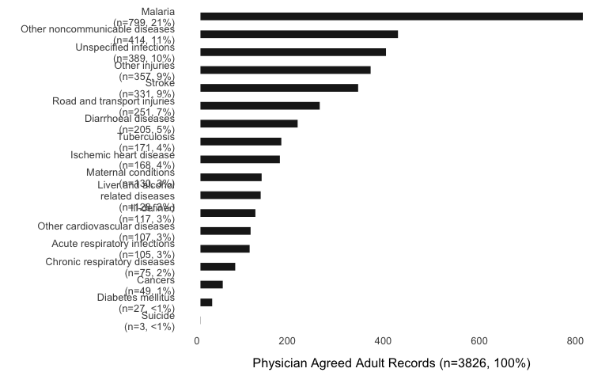

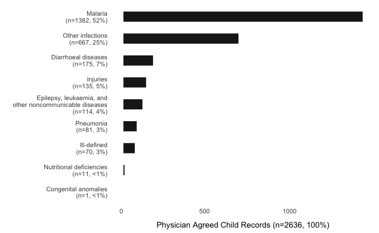

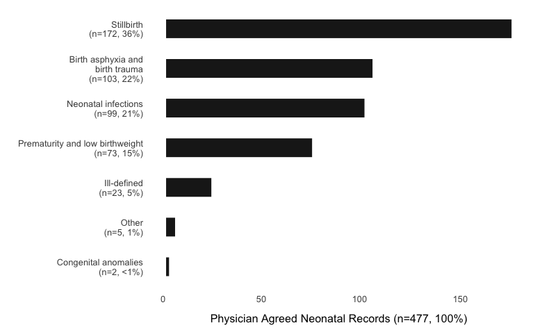

```r
for (a in c("adult", "child", "neo")) {

    # Create label for age group
    arows <- df %>% filter(is_agreed == TRUE & age == a) %>% nrow
    alabel <- if (a == "neo") "Neonatal" else str_to_title(a)
    atitle <- paste0("Physician Agreed ", alabel, " Records (n=", arows, ", 100%)")

    # Format plot data
    ecoddata <- df %>%
        filter(is_agreed == TRUE & age == a) %>%
        group_by(physician_cghr10) %>%
        summarize(count = n()) %>%
        mutate(
            cod_label = paste0(
                if_else(
                    str_count(physician_cghr10, "\\s+") > 3,
                    str_replace(physician_cghr10, "(\\S+\\s+\\S+\\s+\\S+) ", "\\1\n"),
                    physician_cghr10
                ),
                "\n(n=", count, ", ",
                if_else(
                    ((count / arows) * 100) < 1,
                    "<1",
                    as.character(round((count / arows) * 100))
                ), "%)"
            )
        ) %>%
        arrange(count) %>%
        mutate(
            cod_label = factor(cod_label, levels = unique(cod_label))
        )

    # Plot the data
    ecodplot <- ecoddata %>%
        ggplot(aes(x = cod_label, y = count)) +
        geom_bar(
            stat = "identity",
            fill = "#1d1d1d",
            color = "white",
            width = 0.5
        ) +
        labs(
            y = atitle,
            x = element_blank()
        ) +
        theme_minimal() +
        theme(
            panel.grid = element_blank(),
            axis.title.x = element_text(margin = margin(t = 10)),
            axis.title.y = element_text(margin = margin(r = 10)),
            axis.text.x = element_text(hjust = 1)
        ) +
        coord_flip()

    # Save the plot
    print(ecodplot)
    ggsave(
        sprintf("../manuscript/fig-data-cod-%s.pdf", a),
        plot = ecodplot,
        dpi = 300,
        width = if (a == "adult") 6 else NA,
        height = if (a == "adult") 8 else NA
    )
}
```

### Performance

#### All vs Agree Performance

Display a plot of model performance for all records versus records where physicians agreed on the COD code.

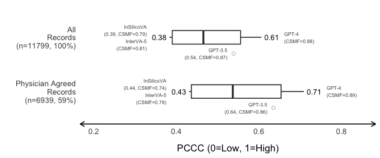

```r
# Calc stage counts
nall <- nrow(df)
nagree <- nrow(df %>% filter(is_agreed == TRUE))
nrecon <- nrow(df %>% filter(is_recon == TRUE))
nadj <- nrow(df %>% filter(is_adj == TRUE))

# Calc stage perc
pagree <- (nagree / nall) * 100
precon <- (nrecon / nall) * 100
padj <- (nadj / nall) * 100

# Create stage with counts
stage_remap <- c(
    "All" = paste0("All\nRecords\n(n=", nall, ", 100%)"),
    "Agreed" = paste0("Physician Agreed\nRecords\n(n=", nagree, ", ", round(pagree), "%)"),
    "Reconciled" = paste0("Reconciled\n(n=", nrecon, ", ", round(precon), "%)"),
    "Adjudicated" = paste0("Adjudicated\n(n=", nadj, ", ", round(padj), "%)")
)

# Prepare boxplot data
alldata <- out %>%
    select(
        Model,
        `PCCC`,
        `PCCC Agreement`,
        `CSMF Accuracy`,
        `CSMF Accuracy Agreement`
    ) %>%
    rename(
         All = `PCCC`,
         Agreed = `PCCC Agreement`
    ) %>%
    filter(!str_detect(Model, "&")) %>% # remove multi models
    pivot_longer( # transform to long format
        cols = -c(
            Model,
            `CSMF Accuracy`,
            `CSMF Accuracy Agreement`
        ),
        names_to = "Stage",
        values_to = "PCCC"
    ) %>%
    group_by(Stage) %>%
    mutate( # Add min, mid, and max model names to label
        "PCCC Min" = if_else(
            PCCC <= min(PCCC) + 0.05,
            paste0(
                Model, "\n(",
                if_else(round(PCCC, 2) != round(min(PCCC), 2), paste0(round(PCCC, 2), ", "), ""),
                "CSMF=", round(if_else(Stage == "All", `CSMF Accuracy`, `CSMF Accuracy Agreement`), 2), ")"),
            NA
        ),
        "PCCC Max" = if_else(
            PCCC >= max(PCCC) - 0.05,
            paste0(
                Model, "\n(",
                if_else(round(PCCC, 2) != round(max(PCCC), 2), paste0(round(PCCC, 2), ", "), ""),
                "CSMF=", round(if_else(Stage == "All", `CSMF Accuracy`, `CSMF Accuracy Agreement`), 2), ")"),
            NA
        ),
        "PCCC Mid" = if_else(
            is.na(`PCCC Min`) & is.na(`PCCC Max`),
            paste0(Model, "\n(", round(PCCC, 2), ", CSMF=", round(if_else(Stage == "All", `CSMF Accuracy`, `CSMF Accuracy Agreement`), 2), ")"),
            NA
        ),
        "PCCC Mid Value" = if_else(
            is.na(`PCCC Min`) & is.na(`PCCC Max`),
            PCCC,
            NA
        ),
        "PCCC Min" = if_else( # Combine into one row if close PCCC
            `PCCC` == min(PCCC),
            if_else(
                sum(!is.na(`PCCC Min`)) > 1,
                paste0(na.omit(`PCCC Min`), collapse = "\n"),
                paste0(
                    str_replace(na.omit(`PCCC Min`), "\\s*\\(.*\\,\\s*", "\n("),
                    collapse = "\n"
                )
            ),
            NA
        ),
        "PCCC Max" = if_else(
            `PCCC` == max(PCCC),
            if_else(
                sum(!is.na(`PCCC Max`)) > 1,
                paste0(na.omit(`PCCC Max`), collapse = "\n"),
                paste0(
                    str_replace(na.omit(`PCCC Max`), "\\s*\\(.*\\,\\s*", "\n("),
                    collapse = "\n"
                )
            ),
            NA
        )
    ) %>%
    mutate( # re-order stage
        Stage = factor(Stage, levels = c(
            "Agreed",
            "All"
        ))
    ) %>%
    mutate( # rename stages with counts
        Stage = recode(Stage, !!!stage_remap)
    )

# Plot boxplot
allplot <- alldata %>%
    ggplot(aes(x = Stage, y = PCCC)) +
    geom_boxplot(
        linewidth = 0.5,
        width = 0.25
    ) +
    geom_point(
        aes(y = `PCCC Mid Value`),
        shape = 1,
        size = 1.5,
        fill = "white",
        color = "darkgray",
        alpha = 0.8,
        position = position_nudge(x = -0.3)
    ) +
    geom_text(
        aes(label = `PCCC Min`),
        color = "#4d4d4d",
        size = 2,
        hjust = 1,
        position = position_nudge(y = -0.055)
    ) +
    geom_text(
        aes(label = `PCCC Max`),
        color = "#4d4d4d",
        size = 2,
        hjust = 0,
        position = position_nudge(y = 0.055)
    ) +
    geom_text(
        aes(label = `PCCC Mid`),
        color = "#4d4d4d",
        size = 2,
        hjust = 1,
        position = position_nudge(y = -0.015, x = -0.3)
    ) +
    stat_summary( # min pccc txt on boxplot
        geom = "text",
        fun = min,
        aes(label = sprintf("%1.2f", after_stat(y))),
        position = position_nudge(y = -0.025),
        size = 3
    ) +
    stat_summary( # max pccc txt on boxplot
        geom = "text",
        fun = max,
        aes(label = sprintf("%1.2f", after_stat(y))),
        position = position_nudge(y = 0.025),
        size = 3
    ) +
    labs(
        x = element_blank(),
        y = "PCCC (0=Low, 1=High)"
    ) +
    ylim(0.2, 0.85) +
    coord_flip() +
    theme_minimal() +
    theme(
        panel.grid = element_blank(),
        axis.line = element_line(color = "black"),
        axis.title.x = element_text(margin = margin(t = 10)),
        axis.title.y = element_text(margin = margin(r = 10)),
        axis.line.x = element_line(
            arrow = grid::arrow(length = unit(0.2, "cm"), ends = "both")
        ),
        axis.line.y = element_blank()
    )

# Save the plot
allplot
```

```r
ggsave("../manuscript/fig-perf-allvsagree.pdf", plot = allplot, dpi = 300)
```

#### Age Group Perfomance

Display a plot of performance for physician agreed records by age group.

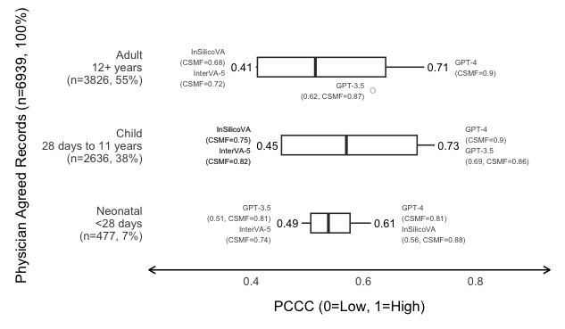

```r
# Calc age counts
nagree <- nrow(df %>% filter(is_agreed == TRUE))
nadult <- nrow(df %>% filter(age == "adult" & is_agreed == TRUE))
nchild <- nrow(df %>% filter(age == "child" & is_agreed == TRUE))
nneo <- nrow(df %>% filter(age == "neo" & is_agreed == TRUE))

# Calc age perc
padult <- (nadult / nagree) * 100
pchild <- (nchild / nagree) * 100
pneo <- (nneo / nagree) * 100

# Create age with counts
age_remap <- c(
    "Adult" = paste0("Adult\n12+ years\n(n=", nadult, ", ", round(padult), "%)"),
    "Child" = paste0("Child\n28 days to 11 years\n(n=", nchild, ", ", round(pchild), "%)"),
    "Neonatal" = paste0("Neonatal\n<28 days\n(n=", nneo, ", ", round(pneo), "%)")
)

# Prepare boxplot data
agedata <- out %>%
    select(
        Model,
        `PCCC Adult Agreement`,
        `PCCC Child Agreement`,
        `PCCC Neo Agreement`,
        `CSMF Accuracy Adult Agreement`,
        `CSMF Accuracy Child Agreement`,
        `CSMF Accuracy Neo Agreement`
    ) %>%
    rename(
         Adult = `PCCC Adult Agreement`,
         Child = `PCCC Child Agreement`,
         Neonatal = `PCCC Neo Agreement`
    ) %>%
    filter(!str_detect(Model, "&")) %>% # remove multi models
    pivot_longer( # transform to long format
        cols = -c(
            Model,
            `CSMF Accuracy Adult Agreement`,
            `CSMF Accuracy Child Agreement`,
            `CSMF Accuracy Neo Agreement`
        ),
        names_to = "Age Group",
        values_to = "PCCC"
    ) %>%
    group_by(`Age Group`) %>%
    mutate( # Add min, mid, and max model names to label
        "PCCC Min" = if_else(
            PCCC <= min(PCCC) + 0.05,
            paste0(
                Model, "\n(",
                if_else(round(PCCC, 2) != round(min(PCCC), 2), paste0(round(PCCC, 2), ", "), ""),
                "CSMF=", round(case_when(
                    `Age Group` == "Adult"  ~ `CSMF Accuracy Adult Agreement`,
                    `Age Group` == "Child"  ~ `CSMF Accuracy Child Agreement`,
                    `Age Group` == "Neonatal"  ~ `CSMF Accuracy Neo Agreement`
                ),2), ")"),
            NA
        ),
        "PCCC Max" = if_else(
            PCCC >= max(PCCC) - 0.05,
            paste0(
                Model, "\n(",
                if_else(round(PCCC, 2) != round(max(PCCC), 2), paste0(round(PCCC, 2), ", "), ""),
                "CSMF=", round(case_when(
                    `Age Group` == "Adult"  ~ `CSMF Accuracy Adult Agreement`,
                    `Age Group` == "Child"  ~ `CSMF Accuracy Child Agreement`,
                    `Age Group` == "Neonatal"  ~ `CSMF Accuracy Neo Agreement`
                ),2), ")"),
            NA
        ),
        "PCCC Mid" = if_else(
            is.na(`PCCC Min`) & is.na(`PCCC Max`),
            paste0(
                Model, "\n(", round(PCCC, 2),
                ", CSMF=", round(case_when(
                    `Age Group` == "Adult"  ~ `CSMF Accuracy Adult Agreement`,
                    `Age Group` == "Child"  ~ `CSMF Accuracy Child Agreement`,
                    `Age Group` == "Neonatal"  ~ `CSMF Accuracy Neo Agreement`
                ),2), ")"),
            NA
        ),
        "PCCC Mid Value" = if_else(
            is.na(`PCCC Min`) & is.na(`PCCC Max`),
            PCCC,
            NA
        ),
        "PCCC Min" = if_else( # Combine into one row if close PCCC
            `PCCC` == min(PCCC),
            if_else(
                sum(!is.na(`PCCC Min`)) > 1,
                paste0(na.omit(`PCCC Min`), collapse = "\n"),
                paste0(
                    str_replace(na.omit(`PCCC Min`), "\\s*\\(.*\\,\\s*", "\n("),
                    collapse = "\n"
                )
            ),
            NA
        ),
        "PCCC Max" = if_else(
            `PCCC` == max(PCCC),
            if_else(
                sum(!is.na(`PCCC Max`)) > 1,
                paste0(na.omit(`PCCC Max`), collapse = "\n"),
                paste0(
                    str_replace(na.omit(`PCCC Max`), "\\s*\\(.*\\,\\s*", "\n("),
                    collapse = "\n"
                )
            ),
            NA
        )
    ) %>%
    mutate( # re-order age
        "Age Group" = factor(`Age Group`, levels = c(
            "Neonatal",
            "Child",
            "Adult"
        ))
    ) %>%
    mutate( # rename ages with counts
        "Age Group" = recode(`Age Group`, !!!age_remap)
    )

# Plot boxplot
ageplot <- agedata %>%
    ggplot(aes(x = `Age Group`, y = PCCC)) +
    geom_boxplot(
        linewidth = 0.5,
        width = 0.25
    ) +
    geom_point(
        aes(y = `PCCC Mid Value`),
        shape = 1,
        size = 1.5,
        fill = "white",
        color = "darkgray",
        alpha = 0.8,
        position = position_nudge(x = -0.3)
    ) +
    geom_text(
        aes(label = `PCCC Min`),
        color = "#4d4d4d",
        size = 2,
        hjust = 1,
        position = position_nudge(y = -0.055)
    ) +
    geom_text(
        aes(label = `PCCC Max`),
        color = "#4d4d4d",
        size = 2,
        hjust = 0,
        position = position_nudge(y = 0.055)
    ) +
    geom_text(
        aes(label = `PCCC Mid`),
        color = "#4d4d4d",
        size = 2,
        hjust = 1,
        position = position_nudge(y = -0.015, x = -0.3)
    ) +
    stat_summary( # min pccc txt on boxplot
        geom = "text",
        fun = min,
        aes(label = sprintf("%1.2f", after_stat(y))),
        position = position_nudge(y = -0.025),
        size = 3
    ) +
    stat_summary( # max pccc txt on boxplot
        geom = "text",
        fun = max,
        aes(label = sprintf("%1.2f", after_stat(y))),
        position = position_nudge(y = 0.025),
        size = 3
    ) +
    labs(
        x = paste0("Physician Agreed Records (n=", nagree, ", 100%)"),
        y = "PCCC (0=Low, 1=High)"
    ) +
    ylim(0.25, 0.9) +
    coord_flip() +
    theme_minimal() +
    theme(
        panel.grid = element_blank(),
        plot.margin = margin(t = 16, b = 12, l = 12, r = 12),
        axis.line = element_line(color = "black"),
        axis.title.x = element_text(margin = margin(t = 10)),
        axis.title.y = element_text(margin = margin(r = 10)),
        axis.line.x = element_line(
            arrow = grid::arrow(length = unit(0.2, "cm"), ends = "both")
        ),
        axis.line.y = element_blank()
    )

# Save the plot
ageplot
```

```r
ggsave("../manuscript/fig-perf-agegroup.pdf", plot = ageplot, dpi = 300)
```

#### Sex Performance

Display a plot for each age group of performance for physician agreed records by sex.

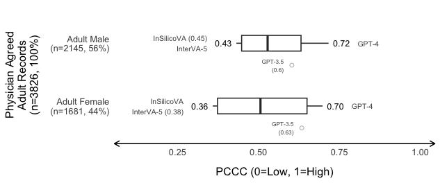

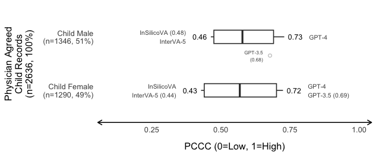

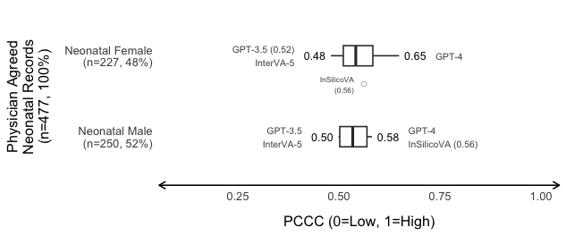

```r
for (a in c("adult", "child", "neo")) {

    # Create label and ref for age group
    arows <- df %>% filter(is_agreed == TRUE & age == a) %>% nrow
    alabel <- if (a == "neo") "Neonatal" else str_to_title(a)
    atitle <- paste0("Physician Agreed\n", alabel, " Records\n(n=", arows, ", 100%)")
    aref <- str_to_title(a)

    # Get unique sex columns
    sex_col <- out %>% select(starts_with(sprintf(
            "PCCC %s Sex Agree ",
            aref
        ))) %>%
        names

    # Create sex with counts
    sex_remap <- list()
    sex_counts <- list()
    for (sx_col in sex_col) {

        # Get sex without prefix
        sx <- gsub(sprintf("PCCC %s Sex Agree ", aref), "", sx_col)

        # Calc num and perc cases for age range
        nsex <- df %>% filter(sex == sx & is_agreed == TRUE & age == a) %>% nrow
        psex <- (nsex / arows) * 100
        psex_label <- if (round(psex) >= 1) round(psex) else "<1"

        # Add label for age ranges
        sex_remap[[sx]] <- paste0(
            sprintf("%s %s", alabel, sx),
            "\n(n=", nsex, ", ", psex_label, "%)"
        )

        # Store age range count data
        sex_counts[[sx]] <- nsex
    }

    # Prepare boxplot data
    sxdata <- out %>%
        select(
            Model,
            starts_with(sprintf("PCCC %s Sex Agree", aref))
        ) %>%
        rename_at(
             vars(-Model),
             ~gsub(sprintf("PCCC %s Sex Agree ", aref), "", .)
        ) %>%
        filter(!str_detect(Model, "&")) %>% # remove multi models
        pivot_longer( # transform to long format
            cols = -Model,
            names_to = "Sex",
            values_to = "PCCC"
        ) %>%
        mutate( # rename cod with counts
            "Sex" = recode(Sex, !!!sex_remap)
        ) %>%
        group_by(Sex) %>%
        mutate( # Make values less than 0 equal to 0
            PCCC = if_else(PCCC <= 0, 0, PCCC)
        ) %>%
        mutate( # Add min, mid, and max model names to label
            "PCCC Min" = if_else(
                PCCC <= min(PCCC) + 0.05,
                paste0(
                    Model,
                    if_else(round(PCCC, 2) != round(min(PCCC), 2), paste0(" (", round(PCCC, 2), ")"), "")
                ),
                NA
            ),
            "PCCC Max" = if_else(
                PCCC >= max(PCCC) - 0.05,
                paste0(
                    Model,
                    if_else(round(PCCC, 2) != round(max(PCCC), 2), paste0(" (", round(PCCC, 2), ")"), "")
                ),
                NA
            ),
            "PCCC Mid" = if_else(
                is.na(`PCCC Min`) & is.na(`PCCC Max`),
                paste0(Model, "\n(", round(PCCC, 2), ")"),
                NA
            ),
            "PCCC Mid Value" = if_else(
                is.na(`PCCC Min`) & is.na(`PCCC Max`),
                PCCC,
                NA
            ),
            "PCCC Min" = if_else( # Combine into one row if close PCCC
                `PCCC` == min(PCCC),
                if_else(
                    sum(!is.na(`PCCC Min`)) > 1,
                    paste0(na.omit(`PCCC Min`), collapse = "\n"),
                    paste0(
                        str_replace(na.omit(`PCCC Min`), "\\s*\\(.*\\)", ""),
                        collapse = "\n"
                    )
                ),
                NA
            ),
            "PCCC Max" = if_else(
                `PCCC` == max(PCCC),
                if_else(
                    sum(!is.na(`PCCC Max`)) > 1,
                    paste0(na.omit(`PCCC Max`), collapse = "\n"),
                    paste0(str_replace(na.omit(`PCCC Max`), "\\s*\\(.*\\)", ""),
                           collapse = "\n")
                ),
                NA
            )
        )

    # Create cod order based on max pccc
    sxorder <- sxdata %>%
        group_by(Sex) %>%
        summarise("PCCC Max Value" = max(PCCC, na.rm = TRUE)) %>%
        select(Sex, `PCCC Max Value`) %>%
        arrange(desc(`PCCC Max Value`)) %>%
        pull(Sex)
    sxdata$Sex <- factor(sxdata$Sex, levels = rev(sxorder))

    # Plot boxplot
    sxplot <- sxdata %>%
        ggplot(aes(x = Sex, y = PCCC)) +
        geom_boxplot(
            linewidth = 0.5,
            width = 0.25
        ) +
        geom_point(
            aes(y = `PCCC Mid Value`),
            shape = 1,
            size = 1.5,
            fill = "white",
            color = "darkgray",
            alpha = 0.8,
            position = position_nudge(x = -0.35)
        ) +
        geom_text(
            aes(label = `PCCC Min`),
            color = "#4d4d4d",
            size = 2.5,
            hjust = 1,
            position = position_nudge(y = -0.09)
        ) +
        geom_text(
            aes(label = `PCCC Mid`),
            color = "#4d4d4d",
            size = 2,
            hjust = 1,
            position = position_nudge(y = -0.025, x = -0.35)
        ) +
        geom_text(
            aes(label = `PCCC Max`),
            color = "#4d4d4d",
            size = 2.5,
            hjust = 0,
            position = position_nudge(y = 0.09)
        ) +
        stat_summary( # min pccc txt on boxplot
            geom = "text",
            fun = min,
            aes(label = sprintf("%1.2f", after_stat(y))),
            position = position_nudge(y = -0.04),
            size = 3
        ) +
        stat_summary( # max pccc txt on boxplot
            geom = "text",
            fun = max,
            aes(label = sprintf("%1.2f", after_stat(y))),
            position = position_nudge(y = 0.04),
            size = 3
        ) +
        labs(
            x = atitle,
            y = "PCCC (0=Low, 1=High)"
        ) +
        ylim(0.1, 1) +
        coord_flip() +
        theme_minimal() +
        theme(
            panel.grid = element_blank(),
            axis.line = element_blank(),
            axis.line.y = element_blank(),
            axis.title.x = element_text(margin = margin(t = 10)),
            axis.title.y = element_text(margin = margin(r = 10)),
            axis.line.x = element_line(
                color = "black",
                arrow = grid::arrow(length = unit(0.2, "cm"), ends = "both")
            )
        )

    # Save the plot
    print(sxplot)
    ggsave(
        sprintf("../manuscript/fig-perf-sex-%s.pdf", a),
        plot = sxplot,
        dpi = 300
    )
}
```

#### Age Range Performance

Display a plot for each age group of performance for physician agreed records by age ranges.

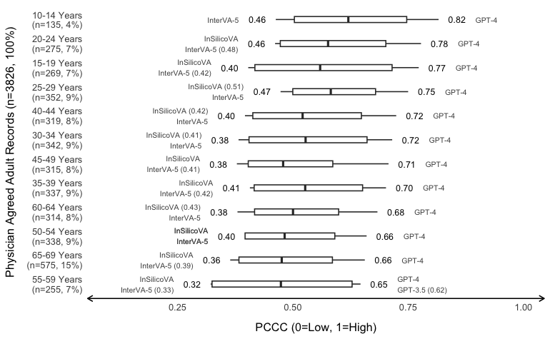

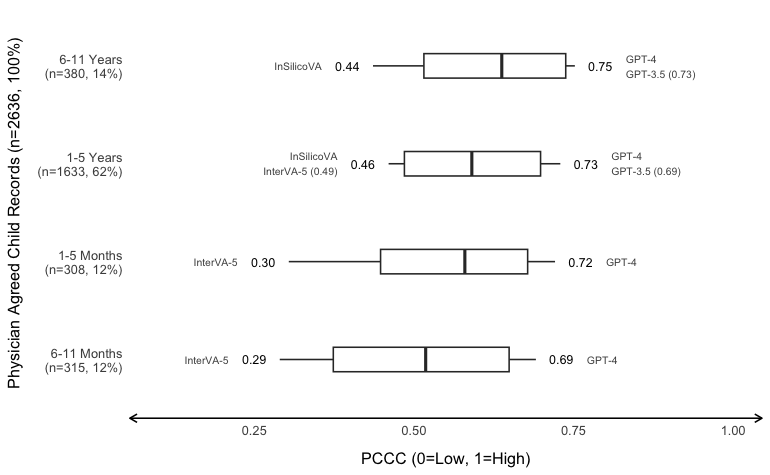

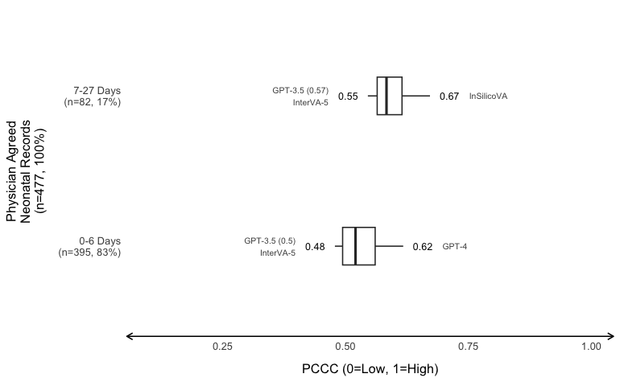

```r
for (a in c("adult", "child", "neo")) {

    # Create label and ref for age group
    arows <- df %>% filter(is_agreed == TRUE & age == a) %>% nrow
    alabel <- if (a == "neo") "Neonatal" else str_to_title(a)
    atitle <- if (a == "neo") {
        paste0("Physician Agreed\n", alabel, " Records\n(n=", arows, ", 100%)")
    } else {
        paste0("Physician Agreed ", alabel, " Records (n=", arows, ", 100%)")
    }
    aref <- str_to_title(a)

    # Get unique age range columns
    arange_col <- out %>% select(starts_with(sprintf(
            "PCCC %s Age Agree ",
            aref
        ))) %>%
        names

    # Create age range with counts
    arange_remap <- list()
    arange_counts <- list()
    for (ar_col in arange_col) {

        # Get cod without prefix
        ar <- gsub(sprintf("PCCC %s Age Agree ", aref), "", ar_col)

        # Calc num and perc cases for age range
        narange <- df %>% filter(age_range == ar & is_agreed == TRUE & age == a) %>% nrow
        parange <- (narange / arows) * 100
        parange_label <- if (round(parange) >= 1) round(parange) else "<1"

        # Add label for age ranges
        arange_remap[[ar]] <- paste0(
            ar,
            "\n(n=", narange, ", ", parange_label, "%)"
        )

        # Store age range count data
        arange_counts[[ar]] <- narange
    }

    # Prepare boxplot data
    ardata <- out %>%
        select(
            Model,
            starts_with(sprintf("PCCC %s Age Agree", aref))
        ) %>%
        rename_at(
             vars(-Model),
             ~gsub(sprintf("PCCC %s Age Agree ", aref), "", .)
        ) %>%
        filter(!str_detect(Model, "&")) %>% # remove multi models
        pivot_longer( # transform to long format
            cols = -Model,
            names_to = "Age Range",
            values_to = "PCCC"
        ) %>%
        mutate( # rename cod with counts
            "Age Range" = recode(`Age Range`, !!!arange_remap)
        ) %>%
        group_by(`Age Range`) %>%
        mutate( # Make values less than 0 equal to 0
            PCCC = if_else(PCCC <= 0, 0, PCCC)
        ) %>%
        mutate( # Add min, mid, and max model names to label
            "PCCC Min" = if_else(
                PCCC <= min(PCCC) + 0.05,
                paste0(
                    Model,
                    if_else(round(PCCC, 2) != round(min(PCCC), 2), paste0(" (", round(PCCC, 2), ")"), "")
                ),
                NA
            ),
            "PCCC Max" = if_else(
                PCCC >= max(PCCC) - 0.05,
                paste0(
                    Model,
                    if_else(round(PCCC, 2) != round(max(PCCC), 2), paste0(" (", round(PCCC, 2), ")"), "")
                ),
                NA
            ),
            "PCCC Mid" = if_else(
                is.na(`PCCC Min`) & is.na(`PCCC Max`),
                paste0(Model, "\n(", round(PCCC, 2), ")"),
                NA
            ),
            "PCCC Min" = if_else( # Combine into one row if close PCCC
                `PCCC` == min(PCCC),
                if_else(
                    sum(!is.na(`PCCC Min`)) > 1,
                    paste0(na.omit(`PCCC Min`), collapse = "\n"),
                    paste0(
                        str_replace(na.omit(`PCCC Min`), "\\s*\\(.*\\)", ""),
                        collapse = "\n"
                    )
                ),
                NA
            ),
            "PCCC Max" = if_else(
                `PCCC` == max(PCCC),
                if_else(
                    sum(!is.na(`PCCC Max`)) > 1,
                    paste0(na.omit(`PCCC Max`), collapse = "\n"),
                    paste0(str_replace(na.omit(`PCCC Max`), "\\s*\\(.*\\)", ""),
                           collapse = "\n")
                ),
                NA
            )
        )

    # Create cod order based on max pccc
    arorder <- ardata %>%
        group_by(`Age Range`) %>%
        summarise("PCCC Max Value" = max(PCCC, na.rm = TRUE)) %>%
        select(`Age Range`, `PCCC Max Value`) %>%
        arrange(desc(`PCCC Max Value`)) %>%
        pull(`Age Range`)
    ardata$`Age Range` <- factor(ardata$`Age Range`, levels = rev(arorder))

    # Plot boxplot
    arplot <- ardata %>%
        ggplot(aes(x = `Age Range`, y = PCCC)) +
        geom_boxplot(
            linewidth = 0.5,
            width = 0.25
        ) +
        geom_text(
            aes(label = `PCCC Min`),
            color = "#4d4d4d",
            size = 2.5,
            hjust = 1,
            position = position_nudge(y = -0.08)
        ) +
        geom_text(
            aes(label = `PCCC Max`),
            color = "#4d4d4d",
            size = 2.5,
            hjust = 0,
            position = position_nudge(y = 0.08)
        ) +
        stat_summary( # min pccc txt on boxplot
            geom = "text",
            fun = min,
            aes(label = sprintf("%1.2f", after_stat(y))),
            position = position_nudge(y = -0.04),
            size = 3
        ) +
        stat_summary( # max pccc txt on boxplot
            geom = "text",
            fun = max,
            aes(label = sprintf("%1.2f", after_stat(y))),
            position = position_nudge(y = 0.04),
            size = 3
        ) +
        labs(
            x = atitle,
            y = "PCCC (0=Low, 1=High)"
        ) +
        ylim(0.1, 1) +
        coord_flip() +
        theme_minimal() +
        theme(
            panel.grid = element_blank(),
            axis.line = element_blank(),
            axis.line.y = element_blank(),
            axis.title.x = element_text(margin = margin(t = 10)),
            axis.title.y = element_text(margin = margin(r = 10)),
            axis.line.x = element_line(
                color = "black",
                arrow = grid::arrow(length = unit(0.2, "cm"), ends = "both")
            )
        )

    # Save the plot
    print(arplot)
    ggsave(
        sprintf("../manuscript/fig-perf-agerange-%s.pdf", a),
        plot = arplot,
        dpi = 300,
        width = if (a == "adult") 6 else if (a == "neo") 6 else NA,
        height = if (a == "adult") 8 else if (a == "neo") 2.5 else NA
    )
}
```

#### COD Performance

Plot model performance for physician agreed records by cause of death category.

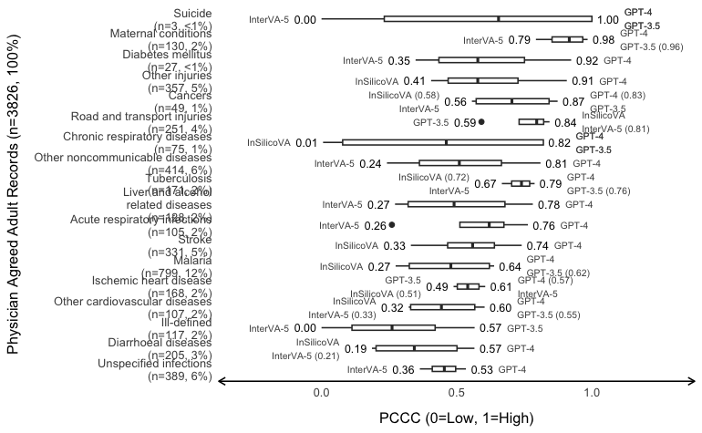

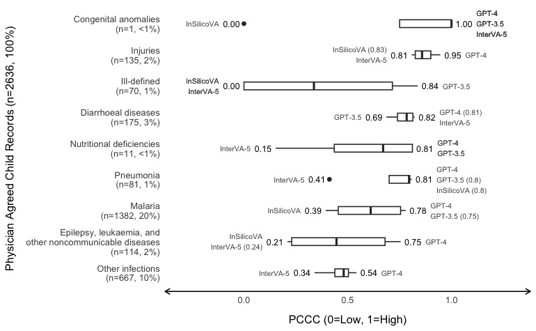

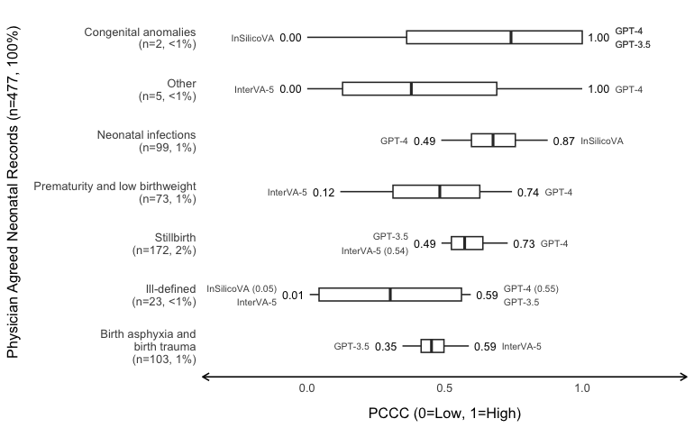

```r
for (a in c("adult", "child", "neo")) {

    # Create label for age group
    arows <- df %>% filter(is_agreed == TRUE & age == a) %>% nrow
    alabel <- if (a == "neo") "Neonatal" else str_to_title(a)
    atitle <- paste0("Physician Agreed ", alabel, " Records (n=", arows, ", 100%)")
    aref <- str_to_title(a)

    # Get unique cause columns
    causes_col <- out %>% select(starts_with(sprintf(
        "PCCC %s COD Agree ", aref
    ))) %>% names

    # Create cod with counts
    cod_remap <- list()
    cod_counts <- list()
    for (cod_col in causes_col) {

        # Get cod without prefix
        cod <- gsub(sprintf("PCCC %s COD Agree ", aref), "", cod_col)

        # Calculate num and perc cases for cod
        ncod <- df %>% filter(physician_cghr10 == cod & is_agreed == TRUE & age == a) %>% nrow
        pcod <- (ncod / nagree) * 100
        pcod_label <- if (round(pcod) >= 1) round(pcod) else "<1"

        # Break cod into newlines if more than 3 words
        if (str_count(cod, "\\s+") > 3) {
            cod_label <- str_replace(cod, "(\\S+\\s+\\S+\\s+\\S+) ", "\\1\n")
        } else {
            cod_label <- cod
        }

        # Add label for cod
        cod_remap[[cod]] <- paste0(cod_label, "\n(n=", ncod, ", ", pcod_label, "%)")

        # Store cod count data
        cod_counts[[cod]] <- ncod
    }

    # Prepare boxplot data
    coddata <- out %>%
        select(
            Model,
            starts_with(sprintf("PCCC %s COD Agree ", aref))
        ) %>%
        rename_at(
             vars(-Model),
             ~gsub(sprintf("PCCC %s COD Agree ", aref), "", .)
        ) %>%
        filter(!str_detect(Model, "&")) %>% # remove multi models
        pivot_longer( # transform to long format
            cols = -Model,
            names_to = "COD",
            values_to = "PCCC"
        ) %>%
        mutate( # rename cod with counts
            "COD" = recode(`COD`, !!!cod_remap)
        ) %>%
        group_by(`COD`) %>%
        mutate( # Make values less than 0 equal to 0
            PCCC = if_else(PCCC <= 0, 0, PCCC)
        ) %>%
        mutate( # Add min, mid, and max model names to label
            "PCCC Min" = if_else(
                PCCC <= min(PCCC) + 0.05,
                paste0(
                    Model,
                    if_else(round(PCCC, 2) != round(min(PCCC), 2), paste0(" (", round(PCCC, 2), ")"), "")
                ),
                NA
            ),
            "PCCC Max" = if_else(
                PCCC >= max(PCCC) - 0.05,
                paste0(
                    Model,
                    if_else(round(PCCC, 2) != round(max(PCCC), 2), paste0(" (", round(PCCC, 2), ")"), "")
                ),
                NA
            ),
            "PCCC Mid" = if_else(
                is.na(`PCCC Min`) & is.na(`PCCC Max`),
                paste0(Model, "\n(", round(PCCC, 2), ")"),
                NA
            ),
            "PCCC Min" = if_else( # Combine into one row if close PCCC
                `PCCC` == min(PCCC),
                if_else(
                    sum(!is.na(`PCCC Min`)) > 1,
                    paste0(na.omit(`PCCC Min`), collapse = "\n"),
                    paste0(
                        str_replace(na.omit(`PCCC Min`), "\\s*\\(.*\\)", ""),
                        collapse = "\n"
                    )
                ),
                NA
            ),
            "PCCC Max" = if_else(
                `PCCC` == max(PCCC),
                if_else(
                    sum(!is.na(`PCCC Max`)) > 1,
                    paste0(na.omit(`PCCC Max`), collapse = "\n"),
                    paste0(str_replace(na.omit(`PCCC Max`), "\\s*\\(.*\\)", ""),
                           collapse = "\n")
                ),
                NA
            )
        )

    # Create cod order based on max pccc
    codorder <- coddata %>%
        group_by(COD) %>%
        summarise("PCCC Max Value" = max(PCCC, na.rm = TRUE)) %>%
        select(COD, `PCCC Max Value`) %>%
        arrange(desc(`PCCC Max Value`)) %>%
        pull(COD)
    coddata$COD <- factor(coddata$COD, levels = rev(codorder))

    # Plot boxplot
    codplot <- coddata %>%
        ggplot(aes(x = COD, y = PCCC)) +
        geom_boxplot(
            linewidth = 0.5,
            width = 0.25
        ) +
        geom_text(
            aes(label = `PCCC Min`),
            color = "#4d4d4d",
            size = 2.5,
            hjust = 1,
            position = position_nudge(y = -0.12)
        ) +
        geom_text(
            aes(label = `PCCC Max`),
            color = "#4d4d4d",
            size = 2.5,
            hjust = 0,
            position = position_nudge(y = 0.12)
        ) +
        stat_summary( # min pccc txt on boxplot
            geom = "text",
            fun = min,
            aes(label = sprintf("%1.2f", after_stat(y))),
            position = position_nudge(y = -0.06),
            size = 3
        ) +
        stat_summary( # max pccc txt on boxplot
            geom = "text",
            fun = max,
            aes(label = sprintf("%1.2f", after_stat(y))),
            position = position_nudge(y = 0.06),
            size = 3
        ) +
        labs(
            x = atitle,
            y = "PCCC (0=Low, 1=High)"
        ) +
        ylim(-0.3, 1.3) +
        coord_flip() +
        theme_minimal() +
        theme(
            panel.grid = element_blank(),
            axis.line = element_blank(),
            axis.line.y = element_blank(),
            axis.title.x = element_text(margin = margin(t = 10)),
            axis.title.y = element_text(margin = margin(r = 10)),
            axis.line.x = element_line(
                color = "black",
                arrow = grid::arrow(length = unit(0.2, "cm"), ends = "both")
            )
        )

    # Save the plot
    print(codplot)
    ggsave(
        sprintf("../manuscript/fig-perf-cod-%s.pdf", a),
        plot = codplot,
        dpi = 300,
        width = if (a == "adult") 8 else NA,
        height = if (a == "adult") 10 else NA
    )
}
```